# Проект №1

26/10/2020

# 1 Предобработка данных

Сначала объединим все данные с листов всех студентов в единый датафрейм.

```r
data_unpack <- function(data_path){
  tbl <-
    list.files(path = data_path,
               pattern = "*.csv",
               full.names = T) %>%
    map_df(~read_csv(., col_types = cols(.default = "c")))
}


mussel_data <- data_unpack("C:/Users/maxim/Desktop/Statistiks-and-R-programming/data")
```

Посмотрим на те данные, которые у нас есть:

```
##     Rings           Sex (1 – male, 2 – female, 3 – uvenil)    Length
##  Length:4177        Length:4177                            Length:4177
##  Class :character   Class :character                       Class :character
##  Mode  :character   Mode  :character                       Mode  :character
##    Diameter            Height          Whole_weight       Shucked_weight
##  Length:4177        Length:4177        Length:4177        Length:4177
##  Class :character   Class :character   Class :character   Class :character
##  Mode  :character   Mode  :character   Mode  :character   Mode  :character
##  Viscera_weight     Shell_weight
##  Length:4177        Length:4177
##  Class :character   Class :character
##  Mode  :character   Mode  :character
```

Увидим, что все значения во всех столбцах имеют тип character, что явно не совсем удобно. Разберемся, из-за чего это могло возникнуть. Посмотрим на все значения, которые не являются числами и из-за которых автоматическое приведение типов делает все столбцы не численными. Для этого напишем отдельную функцию, которая для всех по очереди переменных нашего датафрейма выводит сначала название соответствующего столбца, а затем те значения, которые не могут быть корректно переведы в численный формат.

```
## [1] "Rings"
## [1] "nine"
## [1] "Sex (1 – male, 2 – female, 3 – uvenil)"
## [1] NA      "three" "one"   "male"
## [1] "Length"
## [1] NA                                 NA
## [3] NA                                 NA
## [5] NA                                 NA
## [7] "No data! I forgot to mesure it!("
## [1] "Diameter"
## [1] NA NA NA NA NA
## [1] "Height"
## [1] NA NA
## [1] "Whole_weight"
## [1] NA
## [1] "Shucked_weight"
## [1] NA NA NA
## [1] "Viscera_weight"
## character(0)
## [1] "Shell_weight"
## [1] NA NA
```

Видим, что помимо собственно пропущенных значений, студенты иногда ошибочно записывали, например, пол не в стандартном формате - ‘one’ вместо ‘1’ и так далее. Однако такие значения не должны стать пропущенными - ведь легко восстановить, что именно имел ввиду сборщик данных. Для начала стоит разобраться с 2 столбцом. Дадим ему более понятное имя - уберем расшифровку “номер/пол” из названия, сделаем название просто “Sex”, а сами значения в столбце превратим в фактор по указанному обозначению, то есть 1 - мужской пол, 2 - женский, 3 - ювенильный. Для этого так же придется сначала изменить те ячейки, в которых обозначение пола записано, например, словом “one”.

```r
colnames(mussel_data)[2] <- "Sex"
```

Помимо некорректно записанных ячеек в столбце Sex мы так же можем “спасти” значение “nine” из столбца Rings:

```r
mussel_data$Sex[mussel_data$Sex == "one"] <- 1
mussel_data$Sex[mussel_data$Sex == "three"] <- 3
mussel_data$Sex[mussel_data$Sex == "male"] <- 1
mussel_data$Rings[mussel_data$Rings == "nine"] <- 9
```

Теперь переведем переменную Sex в соответствующем столбце в фактор и переименуем уровни:

```r
mussel_data$Sex <- factor(mussel_data$Sex)
levels(mussel_data$Sex) = c("male", "female", "juvenile")
```

Теперь, когда мы уверены, что спасли часть данных, которые бы превратились в NA при переводе в численный тип значений переменных, мы можем привести все столбцы (кроме второго - факторного) к численному типу.

Теперь (уже с намного большим удовольствием) можем еще раз сделать summary(mussel_data):

```
##      Rings              Sex           Length          Diameter
##  Min.   : 1.000   male    :1528   Min.   :0.0750   Min.   :0.055
##  1st Qu.: 8.000   female  :1306   1st Qu.:0.4500   1st Qu.:0.350
##  Median : 9.000   juvenile:1342   Median :0.5450   Median :0.425
##  Mean   : 9.934   NA's    :   1   Mean   :0.5241   Mean   :0.408
##  3rd Qu.:11.000                   3rd Qu.:0.6150   3rd Qu.:0.480
##  Max.   :29.000                   Max.   :0.8150   Max.   :0.650
##                                   NA's   :7        NA's   :5
##      Height        Whole_weight    Shucked_weight   Viscera_weight
##  Min.   :0.0000   Min.   :0.0020   Min.   :0.0010   Min.   :0.0005
##  1st Qu.:0.1150   1st Qu.:0.4415   1st Qu.:0.1865   1st Qu.:0.0935
##  Median :0.1400   Median :0.7995   Median :0.3360   Median :0.1710
##  Mean   :0.1395   Mean   :0.8285   Mean   :0.3595   Mean   :0.1806
##  3rd Qu.:0.1650   3rd Qu.:1.1530   3rd Qu.:0.5020   3rd Qu.:0.2530
##  Max.   :1.1300   Max.   :2.8255   Max.   :1.4880   Max.   :0.7600
##  NA's   :2        NA's   :1        NA's   :3
##   Shell_weight
##  Min.   :0.0015
##  1st Qu.:0.1300
##  Median :0.2335
##  Mean   :0.2388
##  3rd Qu.:0.3285
##  Max.   :1.0050
##  NA's   :2
```

# 2 Визуализация данных на предмет наличия выбросов

Теперь наконец можно начать визуализировать данные на наличие выбросов. Видим, что одно значение по переменной Sex все-таки пропущено. Построим boxplot для, например, переменной Rings в зависимости от пола, выкинув единственное пропущенное значение (так как его не получится однозначно восстановить)

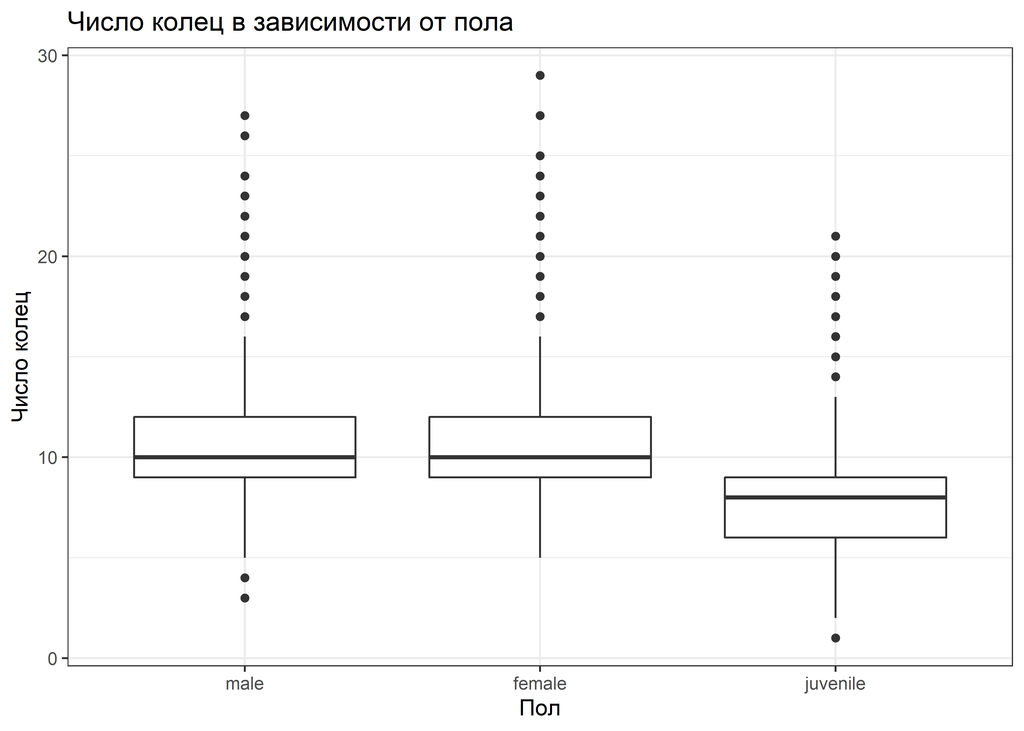

Можно увидеть, что во всех трех группах присутствует достаточное количество выбросов. Посмотрим графики для всех остальных переменных (опять же игнорируя, но пока не выкидывая пропущенные значения - то есть если для какого-то наблюдения потеряна только, например, длина, а остальные данные собраны, то нам нет резона не отображать данные на графиках для тех переменных, которые не потеряны и выкидывать строку полностью).

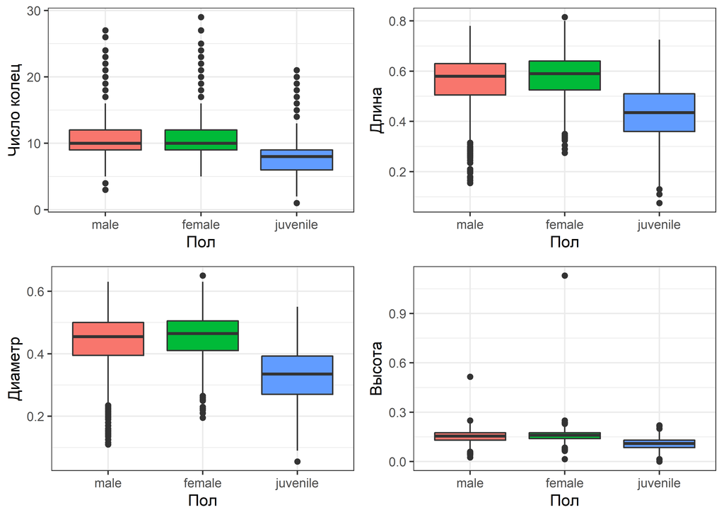

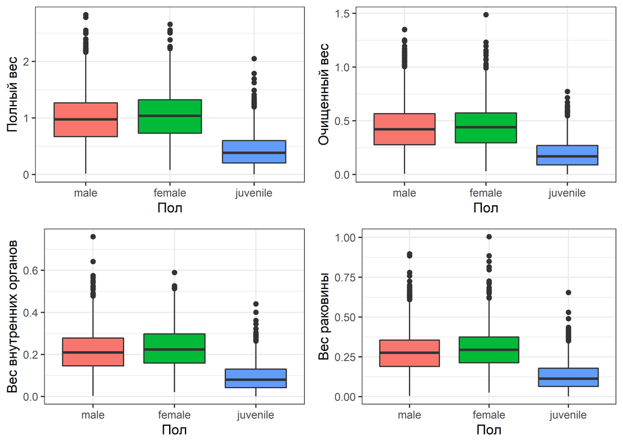

В целом, для каждой из переменных наблюдаем достаточно большое число выбросов. Кажется, что есть огромное число возможных объяснений их наличия. Одной из самых вероятных является то, что в данном исследовании принимало участие несколько человек, данные от которых мы объединили. Каждый из них мог мерить каждую из переменных как-то по-своему, так, что в итоге значения, полученные от разных исследователей, могут отличаться. Помимо непосредственно возможно разных дизайнов эксперимента, могло быть так, что кто-то из тех, кто снимал данные, снимал их адекватно и правильно, а кто-то нет, совершая определенные ошибки в измерениях, неправильно идентифицируя образцы и так далее. Возможно, что все выбросы связаны с конкретными 1-2 исследователями. Однако, так как точнее установить причину выбросов не представляется возможным, пока оставим их, помня, что возможно придется корректировать некоторые данные.

Дальше попробуем оценить наличие взаимосвязей между переменными. Для этого построим матрицу коэффициентов корреляции. Видим, что почти все столбцы неплохо взаимосвязаны - пожалуй, кроме переменной Rings. Первый факт довольно логичен, ведь в целом все наши переменные - это информация о линейных размерах и весе разных частей моллюска. Понятно, что чаще всего, если в целом большой, то не в одном измерении, а сразу по всем параметрам, более того, большие моллюски очевидно почти всегда оказываются тяжелее, чем маленькие моллюски.

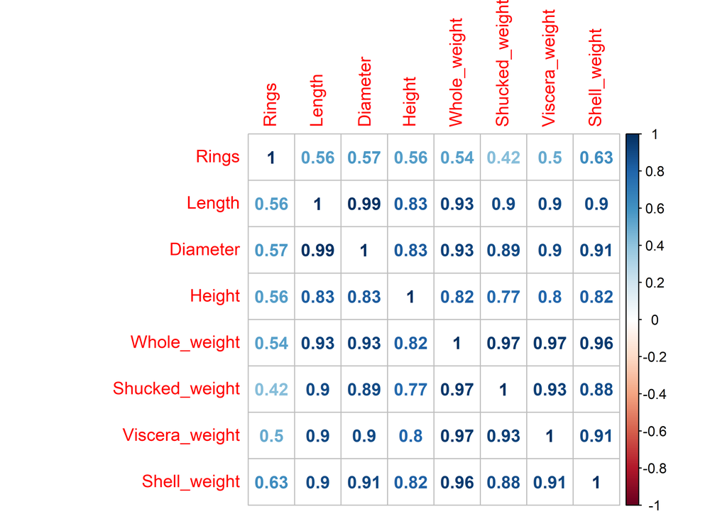

Что касается переменной Rings, то рассмотрим вопросы ее корреляции с другими переменными в отдельном пункте.

# 3 Задание

Для моллюсков разного пола рассчитаем среднее значение и стандартное отклонение длины:

```r
mussel_data_without_NA %>% group_by(Sex) %>% dplyr::summarize(mean = mean(Length), sd = sd(Length))
```

```
## # A tibble: 3 x 3
##   Sex       mean     sd
##   <fct>    <dbl>  <dbl>
## 1 male     0.562 0.103
## 2 female   0.579 0.0862
## 3 juvenile 0.428 0.109
```

# 4 Задание

Посчитаем, у какого процента моллюсков значение переменной Height не превышает 0.165:

```r
num_of_small_mussels <- nrow(mussel_data_without_NA[mussel_data_without_NA$Height <= 0.165, ])
percent_of_small_mussels <- round(num_of_small_mussels / nrow(mussel_data_without_NA) * 100, 2)
print(percent_of_small_mussels)
```

```
## [1] 75.84
```

# 5 Задание

Найдем значение переменной Length, большее, чем у 92% наблюдений:

```r
q_of_len <- quantile(mussel_data$Length, probs = 0.92, na.rm = TRUE)
print(q_of_len)
```

```
##  92%
## 0.67
```

# 6 Задание

Сделаем стандартизацию для переменной Length(выведем только первые несколько значений с помощью функции head, чтобы не захламлять вывод):

```r
Lenght_z_scores <- (mussel_data_without_NA$Length - mean(mussel_data_without_NA$Length)) / sd(mussel_data_without_NA$Length)
head(Lenght_z_scores)
```

```
## [1]  0.4231628 -1.1597936 -0.4099722  1.1729843 -2.0345853 -2.5344663
```

# 7 Задание

Сравним моллюсков, у которых число колец равно 5 с теми, у которых число колец равно 15 по показателю диаметра. Эти две выборки являтся независимыми друг от друга, наблюдения также независимы. Однако размер выборки получается не слишком большим - моллюсков с 5 кольцами имеется:

```
## [1] 114
```

А с 15 кольцами:

```
## [1] 103
```

Мы хотим рассмотреть, имеются ли значимые различия по показателю диаметр у образцов с 5 и с 15 кольцами. Из-за того, что размеры выборок не очень велики, перед тем как сравнивать значение переменной Diameter с помощью t-теста проверим распределения в выборках на нормальность с помощью графиков qq-plot.

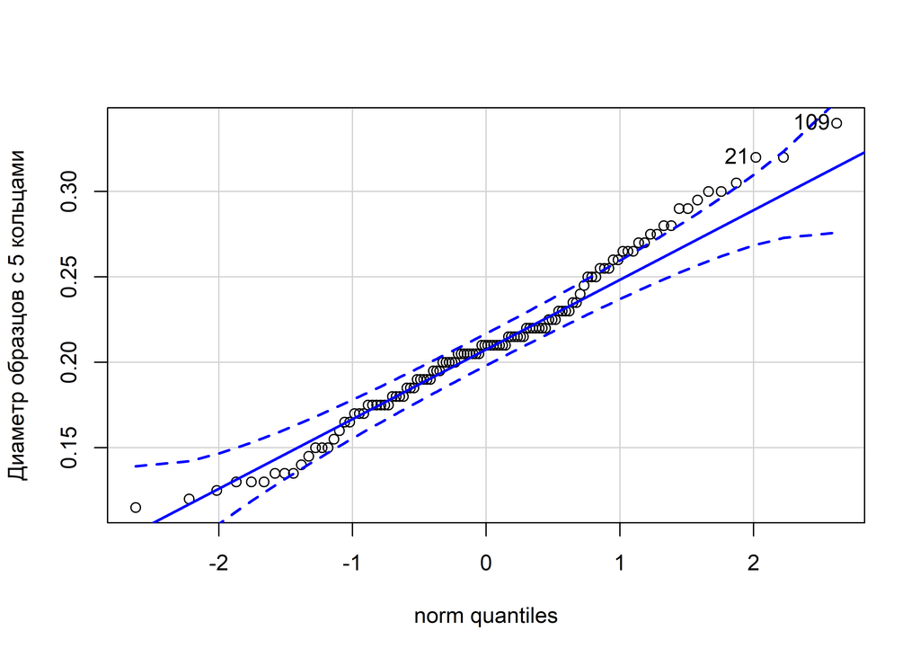

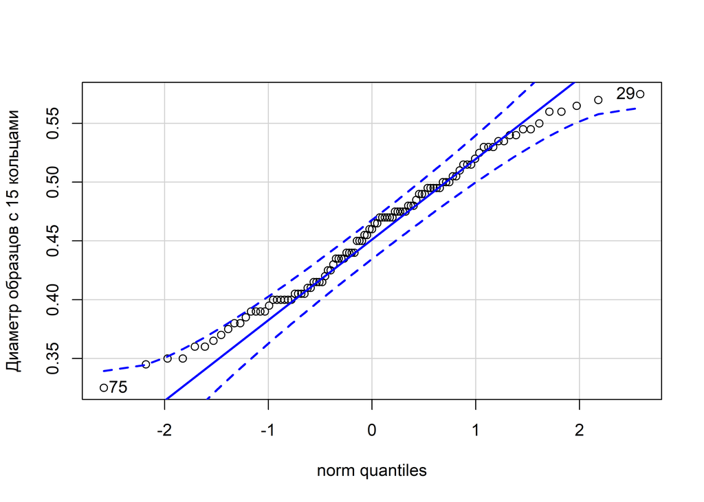

```
##
##  Welch Two Sample t-test
##
## data:  with_5_rings$Diameter and with_15_rings$Diameter
## t = -33.517, df = 195.6, p-value < 2.2e-16
## alternative hypothesis: true difference in means is not equal to 0
## 95 percent confidence interval:
##  -0.2596845 -0.2308223
## sample estimates:
## mean of x mean of y
## 0.2110088 0.4562621
```

То есть диаметр образцов с 15 кольцами значимо отличается от диаметра образцов с 5 кольцами, что можно так же наглядно увидеть на боксплоте:

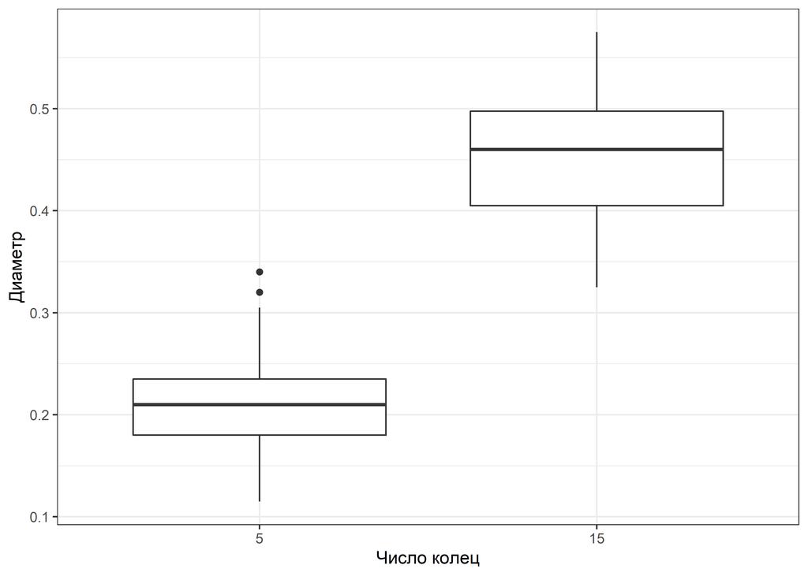

Однако, если задуматься, то этот вывод сам по себе не очень нагляден - среди особей с 5 и 15 кольцами встречаются как взрослые, так и детские образцы. Очевидно, что дети меньше взрослых, поэтому различия в диаметре могут быть обусловлены не числом колец напрямую, а просто тем, что дети меньше взрослых. Чтобы точно подтвердить нашу гипотезу о том, что диаметры образцов с 5 и 15 кольцам значимо отличаются, разделим их так же дополнительно по возрасту - разобьем на детей и взрослых с 5 и 15 кольцам соответственно. Проверим распределения в наших новых 4 группах на нормальность.

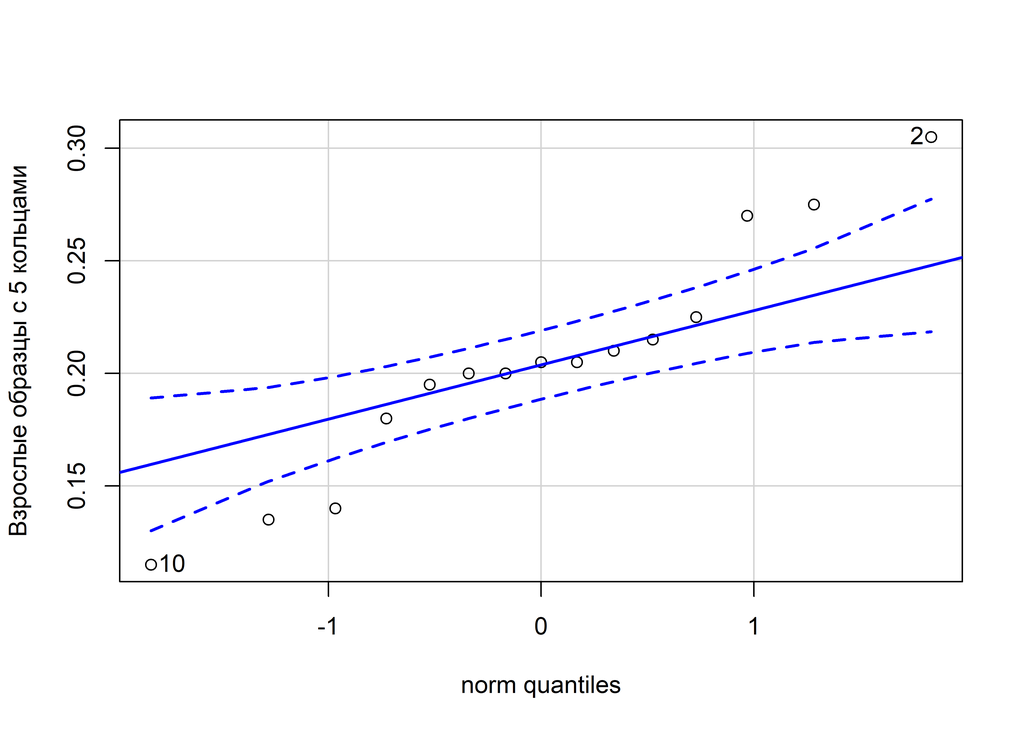

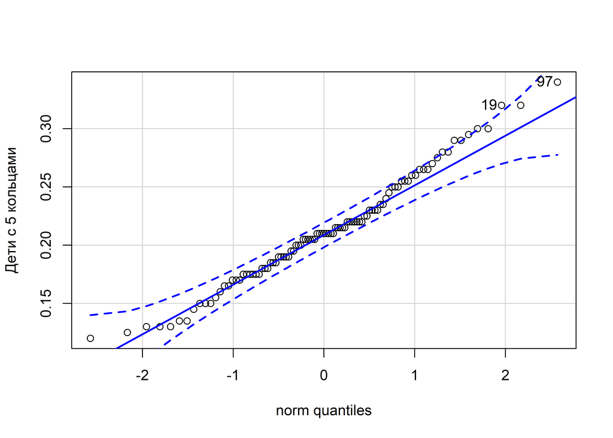

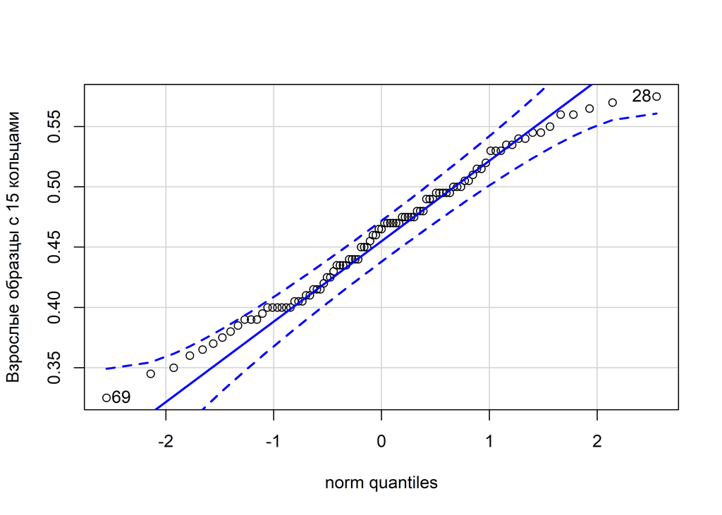

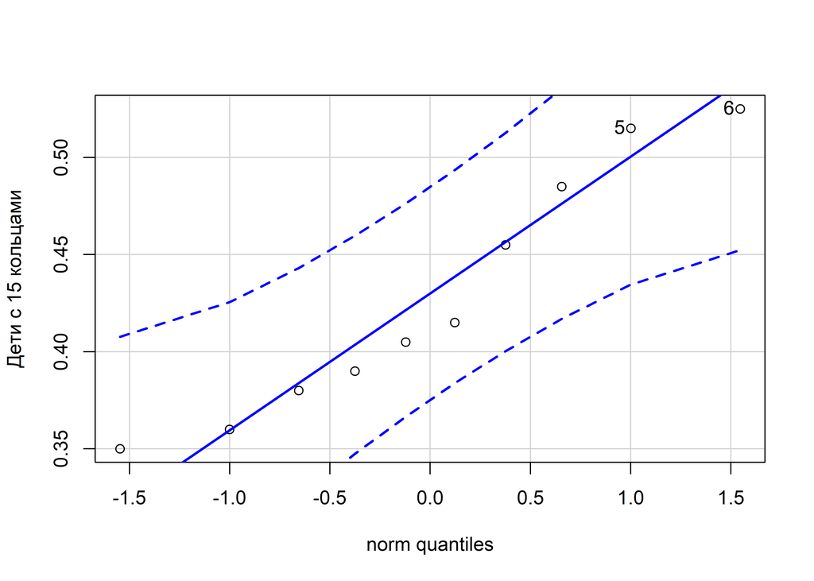

Можно увидеть, что размеры выборок здесь будут довольно различны - образцы с 5 кольцами в основном являются детьми, а образцы с 15 кольцами в основном взрослые. Однако, есть некоторый процент измерений взрослых с 5 кольцами и детей с 15 кольцами(и, например, измерение 5 колец не является выбросом для взрослых особей, если посмотреть повторно на boxplot из пункта 2). Поэтому сравним теперь отдельно образцы с 5 и 15 кольцами в каждой из возрастных групп. Отметим, что взрослые с 5 кольцами к сожалению явно распределены по диаметру не нормальным образом, поэтому для этого сравнения применим критерий Манна-Уитни, а не t-тест. Итак, в группе из взрослых особей:

```
##
##  Wilcoxon rank sum test with continuity correction
##
## data:  adults_with_5_rings$Diameter and adults_with_15_rings$Diameter
## W = 0, p-value = 5.849e-10
## alternative hypothesis: true location shift is not equal to 0
```

А для детских особей:

```
##
##  Welch Two Sample t-test
##
## data:  juvenile_with_5_rings$Diameter and juvenile_with_15_rings$Diameter
## t = -10.5, df = 10.023, p-value = 9.954e-07
## alternative hypothesis: true difference in means is not equal to 0
## 95 percent confidence interval:
##  -0.2619179 -0.1702437
## sample estimates:
## mean of x mean of y
## 0.2119192 0.4280000
```

Для наглядности можем опять же визуализировать эти различия:

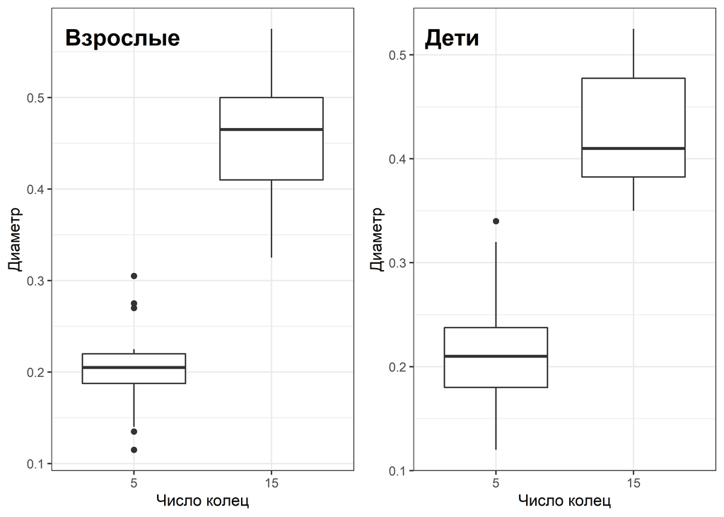

Вывод - диаметр особей с 5 и 15 кольцами значимо отличается, и диаметр у особей с 15 кольцами больше. Причем результат не зависит от того, какого возраста особь - если рассматривать отдельно детей и взрослых с 5 и 15 кольцами, то в каждой из возрастных групп это зависимость будет сохраняться.

# 8 Задание

Изучим отдельно переменные Diameter и Whole_weight. Как уже было посчитано выше, коэффициент корреляции между ними довольно большой, то есть есть основания предполагать взаимосвязь между ними.

```
##
##  Pearson's product-moment correlation
##
## data:  Diameter and Whole_weight
## t = 157.66, df = 4154, p-value < 2.2e-16
## alternative hypothesis: true correlation is not equal to 0
## 95 percent confidence interval:
##  0.9211656 0.9298791
## sample estimates:
##      cor
## 0.925645
```

Визуализируем зависимость этих переменных друг от друга:

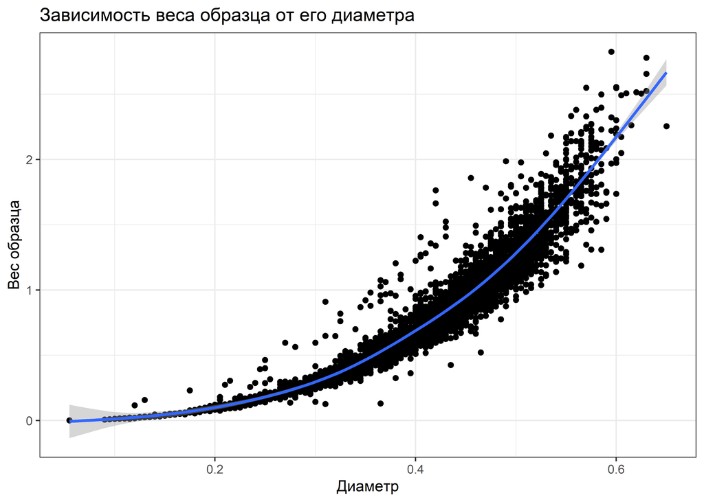

Видно, что можно довольно уверенно сказать, что чем больше диаметр образца, тем больше он весит. Можно сказать, что функция напоминает квадратичную - и это логично. Ведь в очень грубой модели мы можем сказать, что масса моллюска равна его плотности, умноженной на объем. Объем, в свою очередь, будет равен площади моллюска на высоту, а если считать мидию приблизительно круглой, то получается, что линейной зависимостью (с точностью до констант, которыми будут являться число пи и плотность) должны обладать масса моллюска - Whole_weight - и произведение квадрата диаметра на высоту для соответствующего измерения. Проверим это:

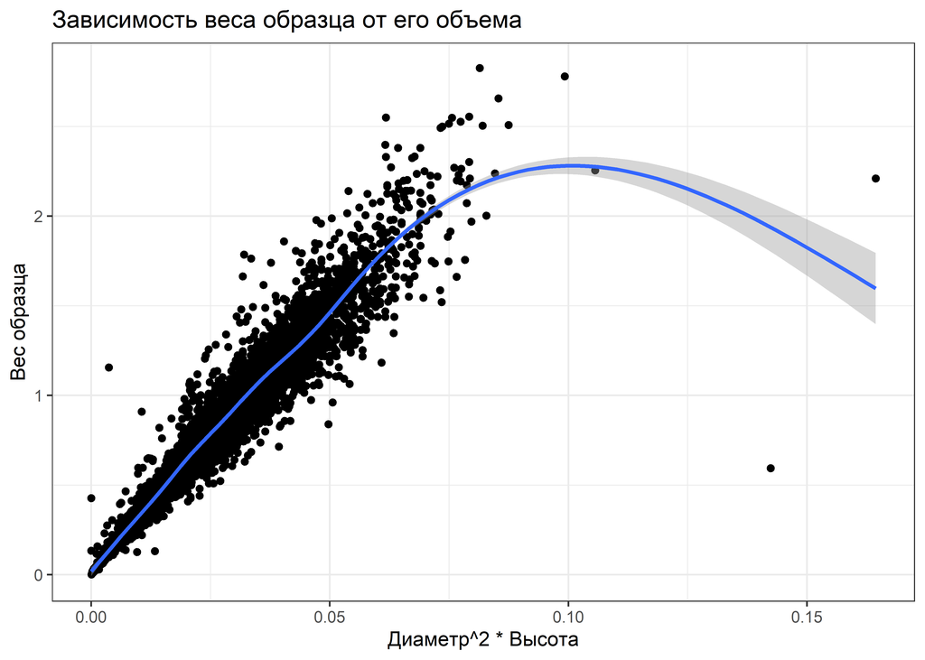

И если отсечь некоторые выбросы, которые очень портят линию тренда, то мы действительно получим очень хорошую линейную зависимость:

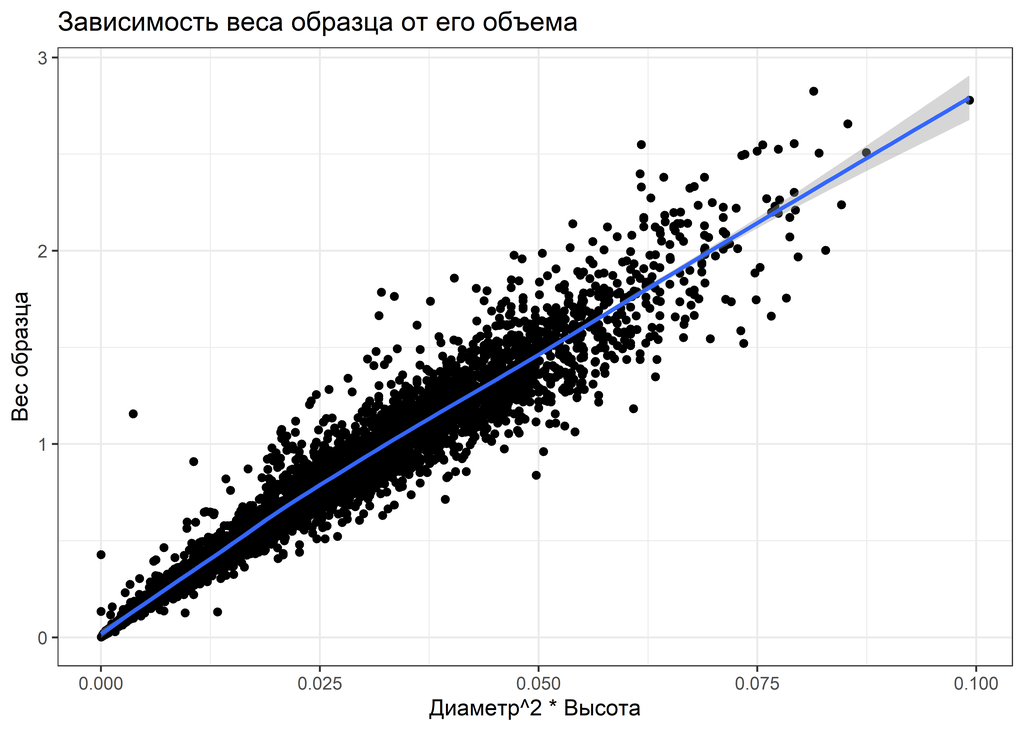

То есть мы можем сделат вывод о том, что параметры веса и диаметра действительно взаимосвязаны, а объясняется это тем, что очевидно с увеличением линейных размеров моллюска увеличивается так же его вес. Так же мы смогли привести зависимость к чисто линейной, заменив диаметр моллюска на объем.

# 9 Дополнительно

```
##
##  Pearson's product-moment correlation
##
## data:  mussel_data_without_NA$Rings and mussel_data_without_NA$Whole_weight
## t = 41.378, df = 4154, p-value < 2.2e-16
## alternative hypothesis: true correlation is not equal to 0
## 95 percent confidence interval:
##  0.5183537 0.5614260
## sample estimates:
##       cor
## 0.5402436
```

Более того, кольца, как мы видели, не так очевидно коррелируют с возрастом - когда мы рассматривали образцы с 5 и 15 кольцами, мы видели, что среди обоих случаев были как взрослые, так и детские особи. Однако, там мы получили результат, что диаметр образцов с 15 кольцами значимо больше, чем среди образцов с 5. Так как диаметр и вес, как мы увидели в прошлом пункте, довольно хорошо объясняют изменчивость друг друга, то в целом ожидаемо, что и вес образцов с разным числом колец будет отличаться, хотя этого и не отображает коэффициент корреляции. Посмотрим, какие вообще значения веса моллюска получаются при каждом из значений числа колец:

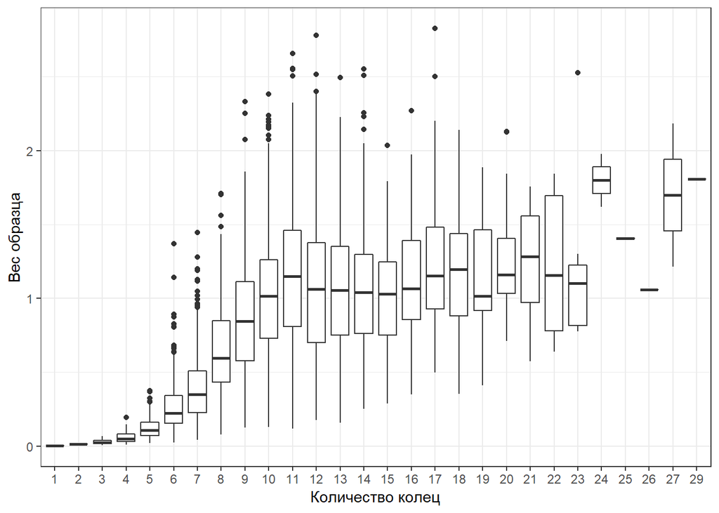

Как мы можем интерпретировать этот график? Мы видим, что сначала, при росте числа колец, вес действительно растет - несмотря на то, что среднее по весу для предыдущего значения числа колец почти всегда попадает в доверительный интервал следующего значения, мы, по-крайней мере, можем объяснить наш результат для 7го пункта, где мы нашли значимые различия в диаметре - для него график зависимости от числа колец выглядит похожим образом:

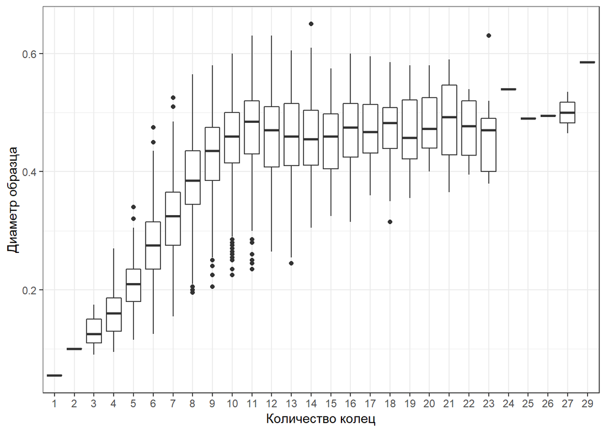

```
##
##  Welch Two Sample t-test
##
## data:  with_15_rings$Whole_weight and with_20_rings$Whole_weight
## t = -2.5572, df = 37.834, p-value = 0.01469
## alternative hypothesis: true difference in means is not equal to 0
## 95 percent confidence interval:
##  -0.37770137 -0.04389572
## sample estimates:
## mean of x mean of y
##  1.040951  1.251750
```

Соответственно, довольно понятно значение коэффициента корреляции - переменные Rings и Whole_weight действительно коррелируют как бы “на половине значений”. чтобы наглядно убедиться в этом действительно возьмем те измерения, у которых число колец меньше или равно 11 и посмотрим, какой для них получается коэффициент корреляции между Rings и Whole_weight:

```
##
##  Pearson's product-moment correlation
##
## data:  less_than_11_rings$Rings and less_than_11_rings$Whole_weight
## t = 50.85, df = 3195, p-value < 2.2e-16
## alternative hypothesis: true correlation is not equal to 0
## 95 percent confidence interval:
##  0.6491885 0.6875293
## sample estimates:
##       cor
## 0.6688034
```

А для Diameter еще лучше:

```
##
##  Pearson's product-moment correlation
##
## data:  less_than_11_rings$Rings and less_than_11_rings$Diameter
## t = 63.259, df = 3195, p-value < 2.2e-16
## alternative hypothesis: true correlation is not equal to 0
## 95 percent confidence interval:
##  0.7298875 0.7606884
## sample estimates:
##      cor
## 0.745686
```

И мы сможем провести действительно довольно наглядную линию тренда для зависимости и веса (особенно если еще уберем выбросы - очень маленькие значения веса, причем являющиеся единичными измерениями для 1 и 2 колец), и диаметра от числа колец:

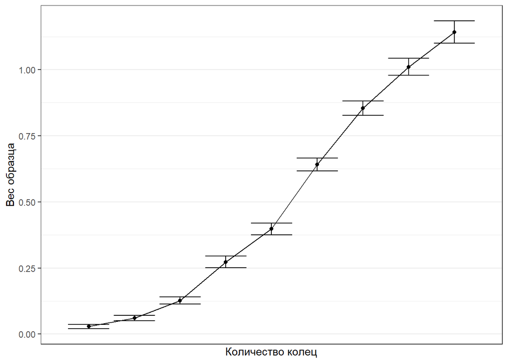

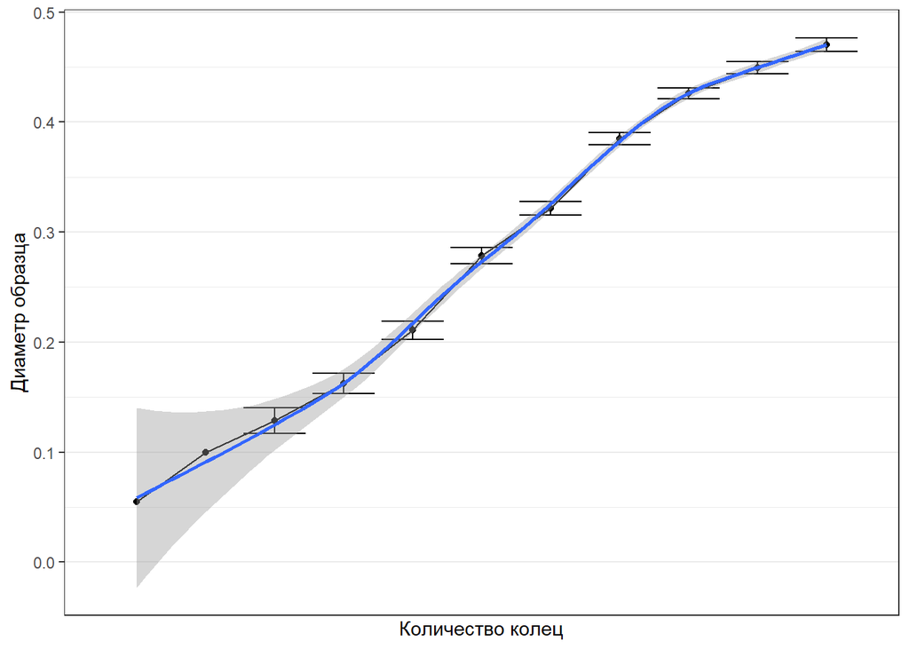

То есть, в итоге, мы можем сделать вывод - количество колец коррелирует с параметрами размера и веса моллюска, но лишь на начальных стадиях роста. Это логично - если, рассмотреть, например, рост или вес человека, то он тоже зависит от возраста похожим образом. Разумеется, мы можем найти очень высокого ребенка и очень низкого взрослого (как здесь мы видели детей с 15 кольцами и взрослых с 5 кольцами), однако, если мы сравним выборки из 5летних и 15летних детей, то мы почти всегда получим, что рост у них значимо отличается, и, конечно, больше у 15летних. Однако, если мы возьмем людей возраста 15 и 20 лет, то у них рост уже вполне вероятно не будет значимо отличаться, а у 20 и 30 летних почти никогда не будет разным в среднем, опять же, при наличии определенных выбросов в обе стороны в обоих группах. Так что на самом деле корреляция переменной Rings с остальными может быть объяснена вполне адекватно.